# lab7-Chen

Weixuan Chen

3/29/2023

## Data

```r
# Download the data
co2=read.table("http://faraway.neu.edu/biostats/lab7_co2.txt", header=TRUE)
temp=read.csv("http://faraway.neu.edu/biostats/lab7_temp.csv")
pop=read.csv("http://faraway.neu.edu/biostats/lab7_population.csv")
```

## Task 1

## 1

```r
str(co2)
```

```
## 'data.frame':    2049 obs. of  9 variables:
##  $ year        : int  1974 1974 1974 1974 1974 1974 1974 1974 1974 1974 ...
##  $ month       : int  5 5 6 6 6 6 6 7 7 7 ...
##  $ day         : int  19 26 2 9 16 23 30 7 14 21 ...
##  $ decimalyear : num  1974 1974 1974 1974 1974 ...
##  $ ppm         : num  333 333 332 332 332 ...
##  $ days        : int  7 6 5 7 7 7 7 7 7 7 ...
##  $ one.year.ago: num  -1000 -1000 -1000 -1000 -1000 ...
##  $ ten.year.ago: num  -1000 -1000 -1000 -1000 -1000 ...
##  $ since.1800  : num  50.3 50.1 49.4 49.6 50 ...
```

```r
str(temp)
```

```
## 'data.frame':    132 obs. of  13 variables:
##  $ Year: int  1881 1882 1883 1884 1885 1886 1887 1888 1889 1890 ...
##  $ Jan : num  13.9 14 13.6 13.8 13.4 ...
##  $ Feb : num  13.8 14.1 13.6 13.9 13.7 ...
##  $ Mar : num  14 14 13.9 13.7 13.8 ...
##  $ Apr : num  14 13.8 13.8 13.7 13.6 ...
##  $ May : num  14 13.8 13.8 13.7 13.7 ...
##  $ Jun : num  13.8 13.7 13.9 13.7 13.6 ...
##  $ Jul : num  13.9 13.7 14 13.7 13.7 ...
##  $ Aug : num  13.9 13.9 13.9 13.8 13.8 ...
##  $ Sep : num  13.8 13.9 13.8 13.7 13.8 ...
##  $ Oct : num  13.8 13.8 13.8 13.8 13.9 ...
##  $ Nov : num  13.7 13.8 13.7 13.7 13.9 ...
##  $ Dec : num  13.8 13.6 13.8 13.8 14 ...
```

```r
str(pop)
```

```
## 'data.frame':    61 obs. of  2 variables:
##  $ year   : int  1950 1951 1952 1953 1954 1955 1956 1957 1958 1959 ...
##  $ popsize: num  2.53e+09 2.57e+09 2.62e+09 2.67e+09 2.71e+09 ...
```

```r
range(co2$year)
```

```
## [1] 1974 2013
```

```r
range(temp$Year)
```

```
## [1] 1881 2012
```

```r
range(pop$year)
```

```
## [1] 1950 2010
```

## 2

```r
temp
```

```
##     Year   Jan   Feb   Mar   Apr   May   Jun   Jul   Aug   Sep   Oct   Nov
## 1   1881 13.87 13.84 13.98 13.98 13.98 13.75 13.89 13.93 13.83 13.78 13.73
## 2   1882 14.03 14.05 13.99 13.77 13.81 13.69 13.74 13.90 13.89 13.75 13.75
## 3   1883 13.62 13.62 13.88 13.81 13.80 13.93 13.98 13.87 13.81 13.81 13.72
## 4   1884 13.81 13.86 13.70 13.65 13.67 13.65 13.69 13.76 13.72 13.75 13.71
## 5   1885 13.44 13.72 13.82 13.64 13.66 13.61 13.73 13.76 13.83 13.86 13.87
## 6   1886 13.63 13.58 13.67 13.77 13.79 13.71 13.89 13.80 13.88 13.78 13.73
## 7   1887 13.42 13.58 13.75 13.68 13.72 13.75 13.82 13.72 13.77 13.68 13.72
## 8   1888 13.58 13.60 13.62 13.76 13.74 13.80 13.90 13.87 13.90 13.97 13.99
## 9   1889 13.83 14.16 14.08 14.08 13.99 13.91 13.88 13.82 13.82 13.79 13.69
## 10  1890 13.60 13.64 13.64 13.67 13.57 13.72 13.76 13.68 13.69 13.80 13.56
## 11  1891 13.58 13.51 13.82 13.73 13.80 13.74 13.75 13.79 13.84 13.73 13.60
## 12  1892 13.65 13.86 13.65 13.62 13.66 13.70 13.66 13.72 13.80 13.83 13.53
## 13  1893 13.16 13.42 13.73 13.65 13.56 13.66 13.83 13.72 13.77 13.79 13.80
## 14  1894 13.46 13.67 13.76 13.54 13.63 13.60 13.75 13.79 13.75 13.78 13.66
```

[output cut: 251 more lines]

```r
# Reshape from wide to long format
temp.long=reshape(temp, varying=list(names(temp)[2:13]), idvar="Year", v.names = "temp", timevar = "Month", direction="long", times = 1:12)
# Change column names
colnames(temp.long)=c("year", "month", "temp")
```

```r
temp.long
```

```
##         year month  temp
## 1881.1  1881     1 13.87
## 1882.1  1882     1 14.03
## 1883.1  1883     1 13.62
## 1884.1  1884     1 13.81
## 1885.1  1885     1 13.44
## 1886.1  1886     1 13.63
## 1887.1  1887     1 13.42
## 1888.1  1888     1 13.58
## 1889.1  1889     1 13.83
## 1890.1  1890     1 13.60
## 1891.1  1891     1 13.58
## 1892.1  1892     1 13.65
## 1893.1  1893     1 13.16
## 1894.1  1894     1 13.46
## 1895.1  1895     1 13.50
## 1896.1  1896     1 13.69
## 1897.1  1897     1 13.79
## 1898.1  1898     1 13.87
## 1899.1  1899     1 13.79
## 1900.1  1900     1 13.62
## 1901.1  1901     1 13.68
## 1902.1  1902     1 13.79
## 1903.1  1903     1 13.74
## 1904.1  1904     1 13.34
## 1905.1  1905     1 13.67
## 1906.1  1906     1 13.70
## 1907.1  1907     1 13.54
## 1908.1  1908     1 13.56
## 1909.1  1909     1 13.35
## 1910.1  1910     1 13.55
## 1911.1  1911     1 13.38
## 1912.1  1912     1 13.71
## 1913.1  1913     1 13.53
## 1914.1  1914     1 13.97
## 1915.1  1915     1 13.75
## 1916.1  1916     1 13.80
## 1917.1  1917     1 13.56
## 1918.1  1918     1 13.56
## 1919.1  1919     1 13.74
```

[output cut: 1530 more lines]

```
## 1998.12 1998    12 14.55
## 1999.12 1999    12 14.45
## 2000.12 2000    12 14.28
## 2001.12 2001    12 14.53
## 2002.12 2002    12 14.43
## 2003.12 2003    12 14.72
## 2004.12 2004    12 14.48
## 2005.12 2005    12 14.65
## 2006.12 2006    12 14.74
## 2007.12 2007    12 14.46
## 2008.12 2008    12 14.51
## 2009.12 2009    12 14.59
## 2010.12 2010    12 14.45
## 2011.12 2011    12 14.48
## 2012.12 2012    12 14.45
```

## 3

```r
temp.agg=aggregate(temp ~ year, mean, data=temp.long)
co2.agg=aggregate(ppm ~ year, mean, data=co2)
pop.agg=aggregate(popsize ~ year, mean, data=pop)
```

```r
temp.agg
```

```
##     year     temp
## 1   1881 13.86583
## 2   1882 13.83333
## 3   1883 13.80417
## 4   1884 13.72667
## 5   1885 13.74667
## 6   1886 13.75583
## 7   1887 13.68500
## 8   1888 13.80333
## 9   1889 13.89667
## 10  1890 13.67000
## 11  1891 13.73083
## 12  1892 13.68750
## 13  1893 13.64417
## 14  1894 13.67750
```

[output cut: 118 more lines]

```r
co2.agg
```

```
##    year      ppm
## 1  1974 329.4779
## 2  1975 203.1813
## 3  1976 306.4163
## 4  1977 333.7863
## 5  1978 335.4104
## 6  1979 311.0765
## 7  1980 338.6965
## 8  1981 340.1073
## 9  1982 289.7558
## 10 1983 343.0258
## 11 1984 242.9487
## 12 1985 346.0575
## 13 1986 347.3925
## 14 1987 349.1900
```

[output cut: 26 more lines]

```r
pop.agg
```

```
##    year    popsize
## 1  1950 2525779000
## 2  1951 2572851000
## 3  1952 2619292000
## 4  1953 2665865000
## 5  1954 2713172000
## 6  1955 2761651000
## 7  1956 2811572000
## 8  1957 2863043000
## 9  1958 2916030000
## 10 1959 2970396000
## 11 1960 3026003000
## 12 1961 3082830000
## 13 1962 3141072000
## 14 1963 3201178000
```

[output cut: 47 more lines]

## 4

```r
merged=merge(co2.agg, temp.agg, by="year")
merged=merge(merged, pop.agg, by="year")
```

```r
merged
```

```
##    year      ppm     temp    popsize
## 1  1974 329.4779 13.92917 3995305000
## 2  1975 203.1813 13.98583 4071020000
## 3  1976 306.4163 13.87750 4146136000
## 4  1977 333.7863 14.14750 4220817000
## 5  1978 335.4104 14.05083 4295665000
## 6  1979 311.0765 14.12250 4371528000
## 7  1980 338.6965 14.23083 4449049000
## 8  1981 340.1073 14.28583 4528235000
## 9  1982 289.7558 14.09167 4608962000
## 10 1983 343.0258 14.27417 4691560000
## 11 1984 242.9487 14.12167 4776393000
## 12 1985 346.0575 14.08417 4863602000
## 13 1986 347.3925 14.14583 4953377000
## 14 1987 349.1900 14.28583 5045316000
```

[output cut: 23 more lines]

## Task 2

## 1

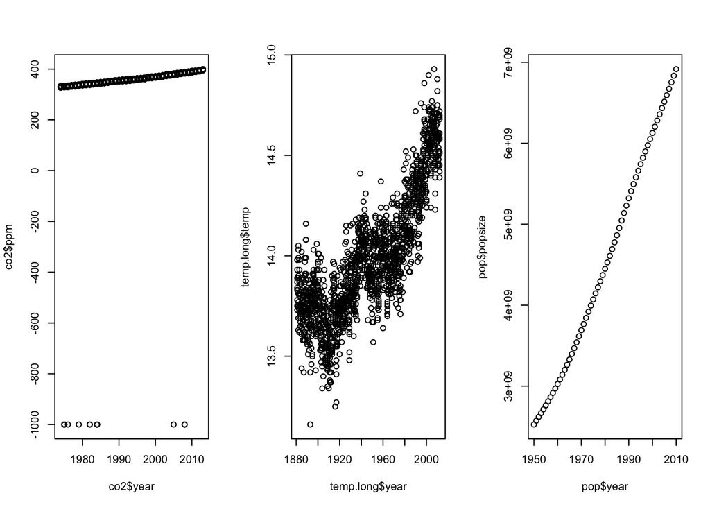

```r
par(mfrow=c(1,3))

plot(co2$year, co2$ppm)
plot(temp.long$year, temp.long$temp)
plot(pop$year, pop$popsize)
```

## 2

According to the graph, co2’s ppm and pop’s popsize variables need transformation. Tranformation can help increase the quality of the dataset because it ensures the data meets the assumptions of the model and thus increase the accuracy of the result. But it also cause the loss of imformation during the transformation.

## 3

H0: there is no relationship between x and y H1: there is relationship between x and y

## 4

```r
temp.lm <- lm(temp ~ year, data = temp.long)
co2.lm <- lm(ppm ~ year, data = co2)
pop.lm <- lm(popsize ~ year, data = pop)
```

```r
summary(temp.lm)
```

```
##
## Call:
## lm(formula = temp ~ year, data = temp.long)
##
## Residuals:
##      Min       1Q   Median       3Q      Max
## -0.53499 -0.12778 -0.00622  0.11946  0.55463
##
## Coefficients:
##              Estimate Std. Error t value Pr(>|t|)
## (Intercept) 1.0384459  0.2244796   4.626 4.03e-06 ***
## year        0.0066527  0.0001153  57.698  < 2e-16 ***
## ---
## Signif. codes:  0 '***' 0.001 '**' 0.01 '*' 0.05 '.' 0.1 ' ' 1
##
## Residual standard error: 0.1749 on 1582 degrees of freedom
## Multiple R-squared:  0.6779, Adjusted R-squared:  0.6777
## F-statistic:  3329 on 1 and 1582 DF,  p-value: < 2.2e-16
```

```r
summary(co2.lm)
```

```
##
## Call:
## lm(formula = ppm ~ year, data = co2)
##
## Residuals:
##      Min       1Q   Median       3Q      Max
## -1382.91     4.28     9.22    17.64    29.52
##
## Coefficients:
##               Estimate Std. Error t value Pr(>|t|)
## (Intercept) -4291.2018   474.0929  -9.051   <2e-16 ***
## year            2.3277     0.2378   9.788   <2e-16 ***
## ---
## Signif. codes:  0 '***' 0.001 '**' 0.01 '*' 0.05 '.' 0.1 ' ' 1
##
## Residual standard error: 122.1 on 2047 degrees of freedom
## Multiple R-squared:  0.04471,    Adjusted R-squared:  0.04424
## F-statistic: 95.81 on 1 and 2047 DF,  p-value: < 2.2e-16
```

```r
summary(pop.lm)
```

```
##
## Call:
## lm(formula = popsize ~ year, data = pop)
##
## Residuals:
##        Min         1Q     Median         3Q        Max
## -105386281  -94525823    6191799   53344802  257375326
##
## Coefficients:
##               Estimate Std. Error t value Pr(>|t|)
## (Intercept) -1.462e+11  1.329e+09  -110.0   <2e-16 ***
## year         7.616e+07  6.713e+05   113.5   <2e-16 ***
## ---
## Signif. codes:  0 '***' 0.001 '**' 0.01 '*' 0.05 '.' 0.1 ' ' 1
##
## Residual standard error: 92310000 on 59 degrees of freedom
## Multiple R-squared:  0.9954, Adjusted R-squared:  0.9954
## F-statistic: 1.287e+04 on 1 and 59 DF,  p-value: < 2.2e-16
```

## 5

```r
# Extract residuals from linear model
temp.resid <- resid(temp.lm)
# TEst the residuals for normality using a Shapiro-Wilk test
shapiro.test(temp.resid)
```

```
##
##  Shapiro-Wilk normality test
##
## data:  temp.resid
## W = 0.99773, p-value = 0.0248
```

```r
# Extract residuals from linear model
co2.resid <- resid(co2.lm)
# TEst the residuals for normality using a Shapiro-Wilk test
shapiro.test(co2.resid)
```

```
##
##  Shapiro-Wilk normality test
##
## data:  co2.resid
## W = 0.095661, p-value < 2.2e-16
```

```r
# Extract residuals from linear model
pop.resid <- resid(pop.lm)
# TEst the residuals for normality using a Shapiro-Wilk test
shapiro.test(pop.resid)
```

```
##
##  Shapiro-Wilk normality test
##
## data:  pop.resid
## W = 0.89454, p-value = 7.355e-05
```

## 6

For the temp~year, we can see the p-values of parameters are significant, which is good indicator of the relationship between y and x. Besides, the R^2 is 0.68, which consider as fine fitting.

For the ppm~year, we can see the p-values are also significant, but R^2 is also too small. This means there is a relationship between y and x but linear regression almost fails to catch this relationship, which is underfitting.

For the popsize~year, we also have the significant p-values, but R^2 is too high. This may mean overfitting issues.

## 7

The assumption is that the distribution of the data will not change.

## 8

```r
# New range of explanatory variable year
newyears=data.frame(year=1880:2050)
# Predict response variable based on each regression
pred.temp.vals=predict(temp.lm, newdata=newyears, interval="confidence")
pred.co2.vals=predict(co2.lm, newdata=newyears, interval="confidence")
pred.pop.vals=predict(pop.lm, newdata=newyears, interval="confidence")
```

## 9

```r
library(gridExtra)
```

```r
library(ggplot2)
```

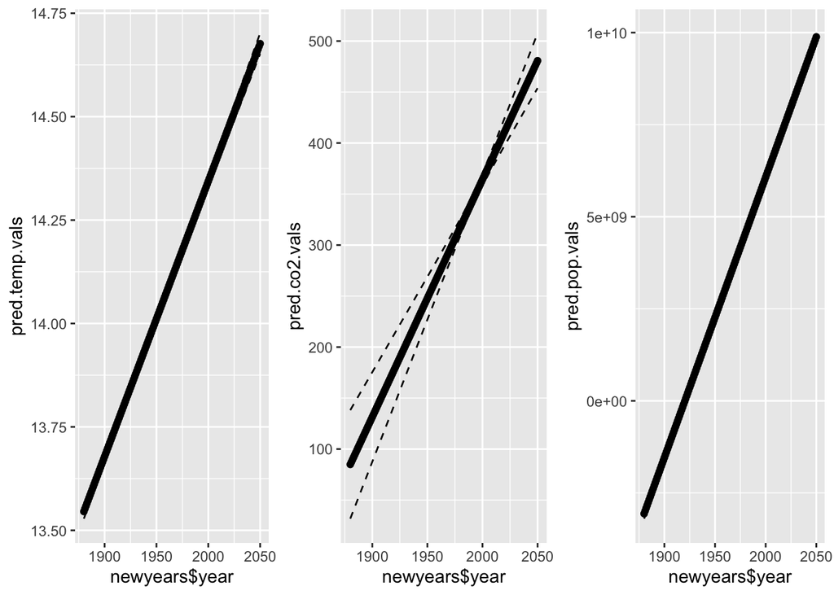

```r
newyears["pred.temp.vals"] = pred.temp.vals[,1]
newyears["pred.co2.vals"] = pred.co2.vals[,1]
newyears["pred.pop.vals"] = pred.pop.vals[,1]

newyears["pred.temp.lwr"] = pred.temp.vals[,2]
newyears["pred.co2.lwr"] = pred.co2.vals[,2]
newyears["pred.pop.lwr"] = pred.pop.vals[,2]

newyears["pred.temp.upr"] = pred.temp.vals[,3]
newyears["pred.co2.upr"] = pred.co2.vals[,3]
newyears["pred.pop.upr"] = pred.pop.vals[,3]

p1 <- ggplot(newyears ,aes(newyears$year,pred.temp.vals))+geom_point()+geom_ribbon(stat="smooth",method="lm",se=TRUE,alpha=0.2)+geom_line(stat="smooth",method="lm") + geom_line(aes(y = pred.temp.lwr), lty = 2) +
  geom_line(aes(y = pred.temp.upr), lty = 2)

p2 <- ggplot(newyears ,aes(newyears$year,pred.co2.vals))+geom_point()+geom_ribbon(stat="smooth",method="lm",se=TRUE,alpha=0.2)+geom_line(stat="smooth",method="lm") + geom_line(aes(y = pred.co2.lwr), lty = 2) +
  geom_line(aes(y = pred.co2.upr), lty = 2)

p3 <- ggplot(newyears ,aes(newyears$year,pred.pop.vals))+geom_point()+geom_ribbon(stat="smooth",method="lm",se=TRUE,alpha=0.2)+geom_line(stat="smooth",method="lm") + geom_line(aes(y = pred.pop.lwr), lty = 2) +
  geom_line(aes(y = pred.pop.upr), lty = 2)

grid.arrange(
  p1,
  p2,
  p3,
  ncol = 3
)
```

## Task 3

## 1

```r
cor(merged$ppm, merged$temp)
```

```
## [1] 0.6730871
```

```r
cor(merged$ppm, merged$popsize)
```

```
## [1] 0.6488286
```

```r
cor(merged$temp, merged$popsize)
```

```
## [1] 0.9122595
```

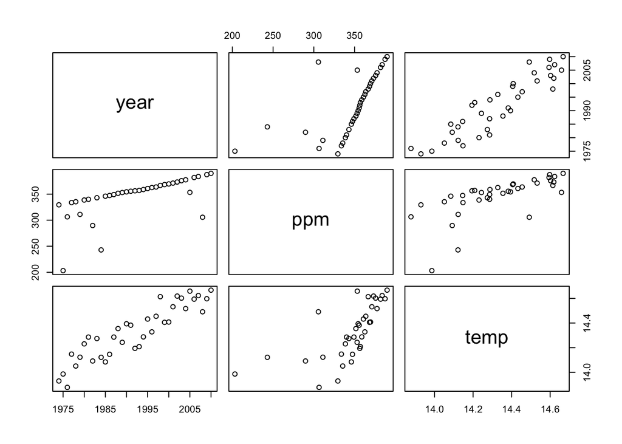

```r
pairs(merged[,1:3])
```

We can see three variables are positively correlated to each other.

## 2

Since the variables are highly correlated, the change of one variable could cause the change of the other. Therefore, this approach cannot measure the rate precisely.

## 3

```r
model <- lm(temp ~ year + popsize + ppm, data = merged)
summary(model)
```

```
##
## Call:
## lm(formula = temp ~ year + popsize + ppm, data = merged)
##
## Residuals:
##       Min        1Q    Median        3Q       Max
## -0.152563 -0.058259 -0.006944  0.069023  0.183070
##
## Coefficients:
##               Estimate Std. Error t value Pr(>|t|)
## (Intercept) -1.514e+02  1.065e+02  -1.422    0.164
## year         8.534e-02  5.528e-02   1.544    0.132
## popsize     -8.389e-10  6.746e-10  -1.244    0.222
## ppm          9.629e-04  5.142e-04   1.873    0.070 .
## ---
## Signif. codes:  0 '***' 0.001 '**' 0.01 '*' 0.05 '.' 0.1 ' ' 1
##
## Residual standard error: 0.0874 on 33 degrees of freedom
## Multiple R-squared:  0.8541, Adjusted R-squared:  0.8409
## F-statistic: 64.41 on 3 and 33 DF,  p-value: 6.98e-14
```

We can see the p-values for each factor is not significant. This indicates we do not have enough evidence to show there is a relationship between y and xs. But we can see R^2 is 0.85, which is pretty good for the model.

## 4

According to the table, it does not have enough evidence to show the causation between temperature and other factors, since we do not reject the null hypothesis for each factor in the summary table above.